# Final Project Team 12

# Background & Introduction

Historically, several states in the United States have passed “Castle Doctrines” to expand the scope of the right to lawful self-defense. The core changes in these laws include the elimination of the duty to retreat in certain places, strengthening legal protections for self-defense, and reducing the legal costs imposed on those who defend themselves. These changes may affect the incentives to commit criminal acts: on the one hand, criminals may be less likely to commit criminal acts for fear of being confronted with forceful counterattacks; on the other hand, lowering the legal threshold for the use of lethal force may increase the likelihood that a conflict will escalate into a lethal incident. Thus, the central question of this study is: does the expansion of castle laws act as a deterrent to crime, or does it increase the incidence of violence?[Cheng Cheng & Mark Hoekstra (2012)](https://www.nber.org/papers/w18134) conducted previous research on this question, using the traditional DiD/FE methodology.Our dataset utilizes the dataset from this dissertation, and builds on their methodology and innovate on top of it.

The content of our dataset is as follows (The dataset was not included in the paper, and we obtained data from [Site 1](https://rdrr.io/cran/causaldata/man/castle.html) and [Site 2](https://github.com/scunning1975/mixtape/tree/master) as well as variable explanations):

**Policy variables**

- cdl: whether the Castle Law is in force (1 = in force, 0 = not in force).
- pre2_cdl: indicator variable for the two years prior to the entry into force of the Castle Law.
- caselaw: whether there is already relevant case law supporting the extension of the right to self-defense.
- anywhere: whether the Castle Law extends outside the home (e.g. vehicle, workplace).
- assumption: whether to include a presumption of “reasonable fear” (i.e., the law implicitly assumes that the person using force is in a state of reasonable fear).
- civil: whether to grant civil immunity (i.e., immunity from prosecution for self-defense).

**Variables related to crime rates**

- homicide_c: Total number of murder and non-negligent manslaughter cases in the state for the year (Homicide count).
- homicide: Murder and non-negligent manslaughter count per 100,000 state population.
- murder: number of murder cases (per 100,000 population) (Murder count per 100,000 state population).
- hc_felonysus: homicides due to felony or suspected felony (per 100,000 population) (Felony and suspected felony-type homicide count per 100,000 state population).
- robbery: number of robberies per 100,000 state population.
- robbery_gun_r: Proportion of robberies using guns.
- assault: Aggravated assault count per 100,000 state population.
- burglary count per 100,000 state population.
- larceny: burglary count per 100,000 state population.
- motor: motor vehicle theft count per 100,000 state population.
- jhcitizen_c: Justifiable homicide by private citizen count.
- jhpolice_c: Justifiable homicide by police count.
- jhcitizen: Justifiable homicide by private citizen per 100,000 state population.
- jhpolice: Justifiable homicide by police per 100,000 state population.

**Socioeconomic control variables**

- population: State population.
- police: Full-time equivalent police per 100,000 state population.
- prisoner: Incarceration rate per 100,000 state population.
- lagprisoner: previous year’s incarceration rate (Lagged incarceration rate per 100,000 state population).
- unemployrt: Unemployment rate.
- income: State median income for state residents.
- poverty: Poverty rate.
- exp_subsidy: Government spending per capita on subsidies.
- exp_pubwelfare: Government spending per capita on public welfare.

**Demographic characteristics (race, age, etc.)**

- blackm_15_24: Percentage of the population that is African American male aged 15-24 (% of black male aged 15-24).
- whitem_15_24: % of white male population aged 15-24 (% of white male aged 15-24).
- blackm_25_44: Percentage of African American male population aged 25-44 (% of black male aged 25-44).
- whitem_25_44: % of white male population aged 25-44 (% of white male aged 25-44).

**Area and Time Variables**

- year: year (2000-2010).
- state: name of the state.
- sid: unique identifier of the state.
- northeast, midwest, south, west: regional dummy variable indicating the U.S. geographic region in which the state is located.
- effyear: year in which the Castle Law went into effect (this variable is null if the state does not have a Castle Law).

The objectives of our study are as follows:

- Treatment variable: whether a state passes a castle law
- Outcome variable: the number of homicides in a state

Our methodological framework is as follows: first, we conduct a baseline model using the traditional DiD/two-way FE methodology to examine average effects at the national level. Next, we innovatively add instrumental variables to the DiD/two-way FE method for further effect optimization. Finally, the scope of our discussion focuses on each state, examined using a synthetic control/synthetic DiD approach.

# EDA & Data Processing

```r
rm(list=ls()) # clear workspace
cat("\014")  # clear console
```

```r
library(tidyverse)
library(ggplot2)
library(haven)
library(plm)
library(psych)
library(gplots)
library(car)
library(dplyr)
library("sensemakr")
library(AER)
library(randomForest)
library(grf)

data <- read_csv("ori_castle.csv")
summary(data)
```

```
    state                year           sid             cdl            pre2_cdl          caselaw       anywhere        assumption         civil        homicide_c      robbery_gun_r       jhcitizen_c      jhpolice_c
 Length:550         Min.   :2000   Min.   : 1.00   Min.   :0.0000   Min.   :0.00000   Min.   :0.0   Min.   :0.0000   Min.   :0.0000   Min.   :0.00   Min.   :   4.00   Min.   :0.008788   Min.   : 0.00   Min.   :  0.000
 Class :character   1st Qu.:2002   1st Qu.:14.00   1st Qu.:0.0000   1st Qu.:0.00000   1st Qu.:0.0   1st Qu.:0.0000   1st Qu.:0.0000   1st Qu.:0.00   1st Qu.:  43.25   1st Qu.:0.250881   1st Qu.: 0.00   1st Qu.:  0.000
 Mode  :character   Median :2005   Median :26.50   Median :0.0000   Median :0.00000   Median :0.0   Median :0.0000   Median :0.0000   Median :0.00   Median : 181.50   Median :0.355030   Median : 2.00   Median :  3.000
                    Mean   :2005   Mean   :26.34   Mean   :0.1522   Mean   :0.07636   Mean   :0.2   Mean   :0.1436   Mean   :0.1109   Mean   :0.16   Mean   : 320.26   Mean   :0.351714   Mean   : 5.06   Mean   :  8.025
                    3rd Qu.:2008   3rd Qu.:39.00   3rd Qu.:0.0000   3rd Qu.:0.00000   3rd Qu.:0.0   3rd Qu.:0.0000   3rd Qu.:0.0000   3rd Qu.:0.00   3rd Qu.: 430.75   3rd Qu.:0.460100   3rd Qu.: 6.00   3rd Qu.:  9.000
                    Max.   :2010   Max.   :51.00   Max.   :1.0000   Max.   :1.00000   Max.   :1.0   Max.   :1.0000   Max.   :1.0000   Max.   :1.00   Max.   :2503.00   Max.   :0.597373   Max.   :48.00   Max.   :124.000
                                                                                                                                                                       NA's   :6
    homicide          robbery           assault          burglary         larceny         motor             murder       hc_felonywsus       jhcitizen           jhpolice          population           police
 Min.   : 0.6467   Min.   :  7.053   Min.   : 44.24   Min.   : 295.3   Min.   :1287   Min.   :  70.56   Min.   : 0.485   Min.   :0.03353   Min.   :0.005147   Min.   :0.005147   Min.   :  479699   Min.   : 55.46
 1st Qu.: 2.6446   1st Qu.: 69.039   1st Qu.:162.74   1st Qu.: 516.1   1st Qu.:1879   1st Qu.: 206.21   1st Qu.: 2.576   1st Qu.:0.28578   1st Qu.:0.056864   1st Qu.:0.075391   1st Qu.: 1719756   1st Qu.:265.90
 Median : 4.6520   Median :100.152   Median :230.26   Median : 663.9   Median :2328   Median : 299.04   Median : 4.439   Median :0.53586   Median :0.096213   Median :0.121888   Median : 4086900   Median :304.37
 Mean   : 4.7614   Mean   :107.160   Mean   :266.94   Mean   : 709.9   Mean   :2334   Mean   : 330.93   Mean   : 4.568   Mean   :0.66294   Mean   :0.117339   Mean   :0.155141   Mean   : 5799396   Mean   :314.86
 3rd Qu.: 6.4257   3rd Qu.:152.563   3rd Qu.:354.34   3rd Qu.: 931.2   3rd Qu.:2719   3rd Qu.: 411.39   3rd Qu.: 6.218   3rd Qu.:0.87305   3rd Qu.:0.156123   3rd Qu.:0.201571   3rd Qu.: 6456960   3rd Qu.:357.41
 Max.   :14.5256   Max.   :282.024   Max.   :647.80   Max.   :1284.5   Max.   :4083   Max.   :1130.95   Max.   :14.088   Max.   :2.97853   Max.   :0.731912   Max.   :0.857004   Max.   :36971641   Max.   :520.91
                                                                                                                         NA's   :11
   unemployrt         income       blackm_15_24        whitem_15_24       blackm_25_44       whitem_25_44         prisoner      lagprisoner       poverty       exp_subsidy    exp_pubwelfare     northeast
 Min.   : 2.300   Min.   :35582   Min.   : 0.007197   Min.   :  0.1897   Min.   : 0.00977   Min.   :  0.5554   Min.   :130.4   Min.   :125.0   Min.   : 5.82   Min.   : 29.7   Min.   : 345.9   Min.   :0.00
 1st Qu.: 4.200   1st Qu.:45958   1st Qu.: 0.133720   1st Qu.:  2.1576   1st Qu.: 0.16848   1st Qu.:  4.4384   1st Qu.:327.0   1st Qu.:324.9   1st Qu.:10.13   1st Qu.: 84.6   1st Qu.:1062.8   1st Qu.:0.00
 Median : 5.000   Median :50907   Median : 0.545259   Median :  4.7850   Median : 0.86291   Median : 10.0445   Median :422.6   Median :416.9   Median :11.91   Median :112.1   Median :1238.7   Median :0.00
 Mean   : 5.491   Mean   :51648   Mean   : 2.604744   Mean   : 10.7708   Mean   : 4.31500   Mean   : 21.9737   Mean   :439.1   Mean   :436.4   Mean   :12.40   Mean   :124.7   Mean   :1318.8   Mean   :0.18
 3rd Qu.: 6.300   3rd Qu.:57081   3rd Qu.: 1.983599   3rd Qu.:  9.5620   3rd Qu.: 3.12335   3rd Qu.: 19.1138   3rd Qu.:516.4   3rd Qu.:516.4   3rd Qu.:14.32   3rd Qu.:155.9   3rd Qu.:1490.8   3rd Qu.:0.00
 Max.   :14.000   Max.   :73598   Max.   :21.227760   Max.   :106.7972   Max.   :35.98399   Max.   :223.8104   Max.   :911.8   Max.   :926.7   Max.   :21.23   Max.   :375.0   Max.   :2671.1   Max.   :1.00

    midwest         south           west         effyear
 Min.   :0.00   Min.   :0.00   Min.   :0.00   Min.   :2005
 1st Qu.:0.00   1st Qu.:0.00   1st Qu.:0.00   1st Qu.:2006
 Median :0.00   Median :0.00   Median :0.00   Median :2006
 Mean   :0.24   Mean   :0.32   Mean   :0.26   Mean   :2006
 3rd Qu.:0.00   3rd Qu.:1.00   3rd Qu.:1.00   3rd Qu.:2007
 Max.   :1.00   Max.   :1.00   Max.   :1.00   Max.   :2009
                                              NA's   :319
```

```r
colSums(is.na(data))
```

```
         state           year            sid            cdl       pre2_cdl        caselaw       anywhere     assumption          civil     homicide_c  robbery_gun_r    jhcitizen_c     jhpolice_c       homicide
             0              0              0              0              0              0              0              0              0              0              6              0              0              0
       robbery        assault       burglary        larceny          motor         murder  hc_felonywsus      jhcitizen       jhpolice     population         police     unemployrt         income   blackm_15_24
             0              0              0              0              0              0             11              0              0              0              0              0              0              0
  whitem_15_24   blackm_25_44   whitem_25_44       prisoner    lagprisoner        poverty    exp_subsidy exp_pubwelfare      northeast        midwest          south           west        effyear
             0              0              0              0              0              0              0              0              0              0              0              0            319
```

```r
data <- data %>%
  mutate(
    effyear = ifelse(is.na(effyear), 0, effyear),
    post = ifelse(year == effyear & effyear > 0, 1, cdl),
    treated = ifelse(effyear > 0, 1, 0)
  )

data <- data %>%
  mutate(
    state = as.factor(state),
    year = as.factor(year),
    sid = as.integer(sid),
    effyear = as.integer(effyear),
    post = as.integer(post),
    treated = as.integer(treated)
  )

num_cols <- setdiff(names(data), c("state", "year", "sid", "effyear", "post", "treated"))
data[num_cols] <- lapply(data[num_cols], as.numeric)

data
```

| state | year | sid | cdl | pre2_cdl | caselaw | anywhere | assumption | civil | homicide_c | robbery_gun_r | jhcitizen_c | jhpolice_c | homicide | robbery | assault | burglary | larceny | motor | murder | hc_felonywsus | jhcitizen | jhpolice | population | police | unemployrt | income | blackm_15_24 | whitem_15_24 | blackm_25_44 | … |
| --- | --- | --- | --- | --- | --- | --- | --- | --- | --- | --- | --- | --- | --- | --- | --- | --- | --- | --- | --- | --- | --- | --- | --- | --- | --- | --- | --- | --- | --- | --- |
| Alabama | 2000 | 1 | 0.0000000 | 0 | 0 | 0 | 0 | 0 | 329 | 0.210803226 | 1 | 0 | 7.5939784 | 131.613571 | 325.61780 | 930.9202 | 2940.624 | 295.65735 | 6.5322065 | 0.48472202 | 0.046164002 | 0.023082001 | 4332380 | 348.83828 | 4.1 | 44851 | 2.222242832 | 4.6948099 | 3.471694469 | … |
| Alabama | 2001 | 1 | 0.0000000 | 0 | 0 | 0 | 0 | 0 | 379 | 0.214362457 | 2 | 0 | 8.7134428 | 128.379593 | 281.63504 | 934.3846 | 2758.690 | 290.11856 | 7.4949403 | 0.66672784 | 0.068971843 | 0.022990614 | 4349601 | 351.82537 | 4.7 | 43301 | 2.249953508 | 4.7002010 | 3.440246582 | … |
| Alabama | 2002 | 1 | 0.0000000 | 0 | 0 | 0 | 0 | 0 | 303 | 0.424018800 | 3 | 2 | 6.9332876 | 136.423309 | 274.63141 | 974.2757 | 2835.829 | 317.83289 | 6.4069986 | 0.59493560 | 0.091528550 | 0.068646416 | 4370221 | 311.49454 | 5.4 | 45573 | 2.258260965 | 4.6854610 | 3.403992653 | … |
| Alabama | 2003 | 1 | 0.0000000 | 0 | 0 | 0 | 0 | 0 | 299 | 0.245445505 | 2 | 1 | 6.8180065 | 137.682693 | 258.53699 | 986.1027 | 2828.424 | 341.05994 | 6.5671768 | 0.31923777 | 0.068408094 | 0.045605395 | 4385446 | 348.56204 | 5.5 | 44165 | 2.292948008 | 4.6881661 | 3.383213520 | … |
| Alabama | 2004 | 1 | 0.0000000 | 1 | 0 | 0 | 0 | 0 | 254 | 0.261006296 | 3 | 0 | 5.7536893 | 136.865311 | 255.65407 | 1011.7885 | 2800.959 | 317.67612 | 5.5951228 | 0.22652319 | 0.090609275 | 0.022652319 | 4414559 | 327.91497 | 5.1 | 42280 | 2.291327477 | 4.6617341 | 3.358840704 | … |
| Alabama | 2005 | 1 | 0.0000000 | 1 | 0 | 0 | 0 | 0 | 374 | 0.187373966 | 0 | 1 | 8.4185734 | 145.119095 | 254.20039 | 978.5579 | 2718.704 | 295.77554 | 6.9329429 | 0.56273884 | 0.022509554 | 0.045019109 | 4442558 | 287.80716 | 3.9 | 41491 | 2.312046289 | 4.6358652 | 3.357209921 | … |
| Alabama | 2006 | 1 | 0.5808219 | 0 | 0 | 1 | 0 | 1 | 368 | 0.215277776 | 3 | 3 | 8.0016870 | 153.423660 | 227.87415 | 968.9217 | 2645.123 | 322.93765 | 6.7840390 | 0.45661804 | 0.086974859 | 0.086974859 | 4599030 | 341.31110 | 3.6 | 41041 | 2.269239426 | 4.4834890 | 3.292868376 | … |
| Alabama | 2007 | 1 | 1.0000000 | 0 | 0 | 1 | 0 | 1 | 392 | 0.213320717 | 3 | 4 | 8.5479403 | 161.407791 | 248.34819 | 989.1188 | 2711.616 | 310.49521 | 7.6538959 | 0.71959704 | 0.087223880 | 0.109029852 | 4585900 | 356.46220 | 3.5 | 44388 | 2.289801359 | 4.5040669 | 3.338494062 | … |
| Alabama | 2008 | 1 | 1.0000000 | 0 | 0 | 1 | 0 | 1 | 357 | 0.317810446 | 3 | 1 | 7.7183280 | 158.777039 | 254.89941 | 1089.1923 | 2734.083 | 290.83179 | 7.2643089 | 0.54049915 | 0.086479865 | 0.043239933 | 4625354 | 349.63810 | 4.9 | 45039 | 2.285014391 | 4.4733872 | 3.351938009 | … |
| Alabama | 2009 | 1 | 1.0000000 | 0 | 0 | 1 | 0 | 1 | 322 | 0.296727866 | 0 | 0 | 6.9496002 | 135.215042 | 282.79694 | 1054.1810 | 2548.302 | 239.37273 | 6.8632698 | 0.49640003 | 0.021582609 | 0.021582609 | 4633360 | 365.11301 | 9.9 | 40640 | 2.277763844 | 4.4550176 | 3.386786222 | … |

[output cut: 540 more lines]

### Distributions and time trends of crime variables

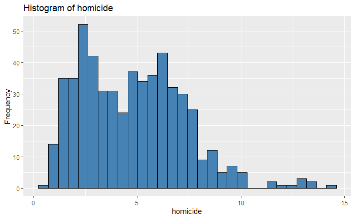

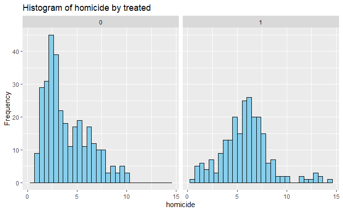

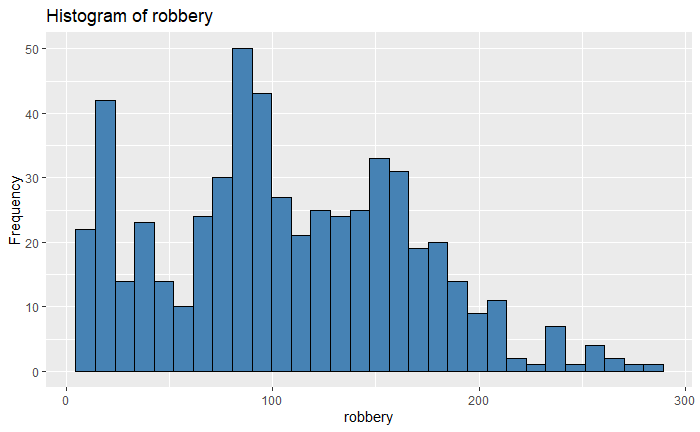

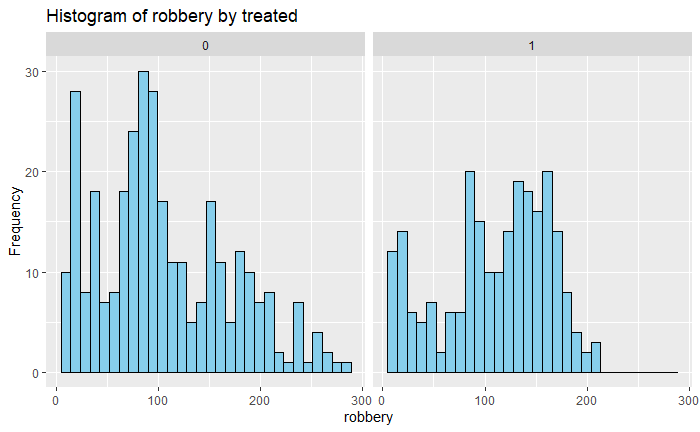

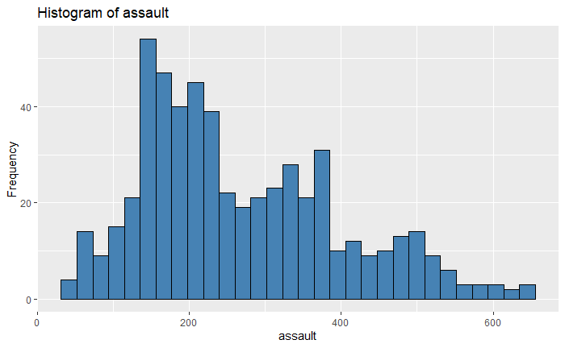

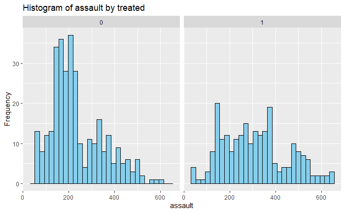

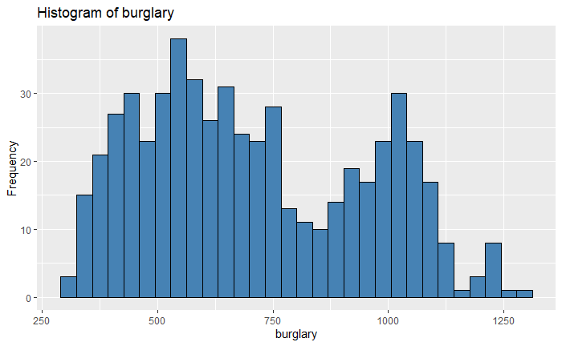

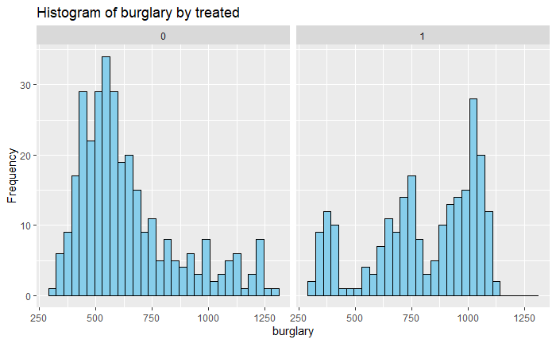

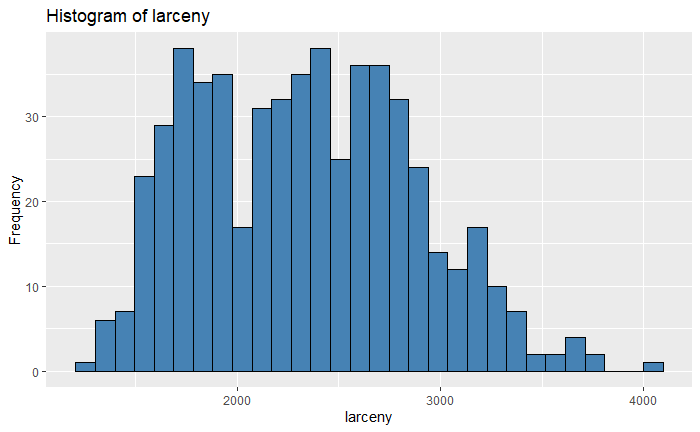

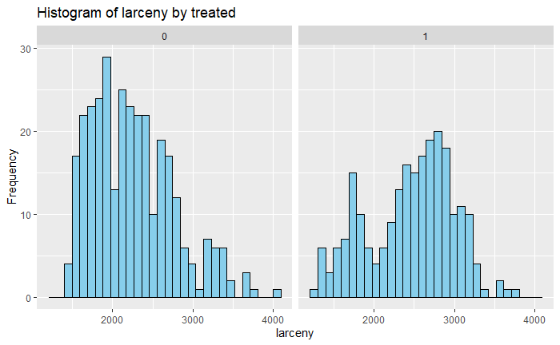

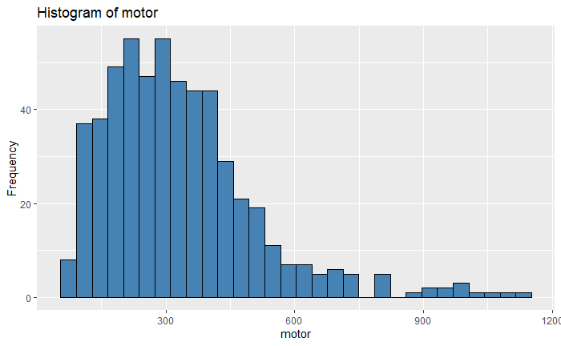

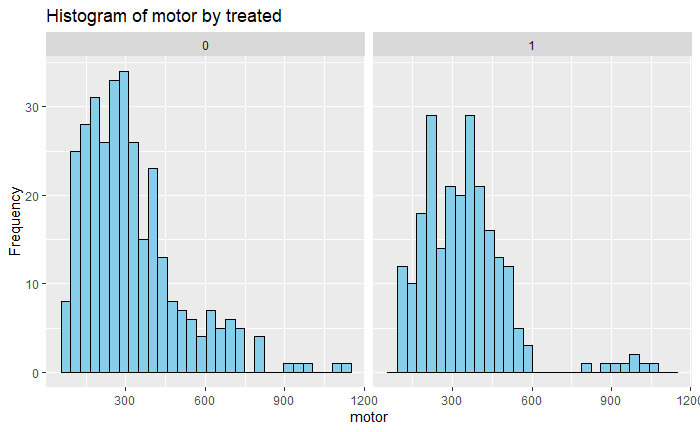

[4 more figures not shown]

```r
crime_vars <- c("homicide", "robbery", "assault", "burglary", "larceny", "motor", "murder", "robbery_gun_r")

for (var in crime_vars) {
  p <- ggplot(data, aes_string(x = var)) +
    geom_histogram(bins = 30, fill = "steelblue", color = "black") +
    labs(title = paste("Histogram of", var), x = var, y = "Frequency")
  print(p)
  q <- ggplot(data, aes_string(x = var)) +
        geom_histogram(bins = 30, fill = "skyblue", color = "black") +
        facet_wrap(~ treated) +
        labs(title = paste("Histogram of", var,"by treated"), x = var, y = "Frequency")
  print(q)
}
```

Trends in different crime rates in states that passed Castle Doctrine laws at some point between 2000 and 2010 (treated = 1) and states that never passed Castle Doctrine laws (treated = 0)

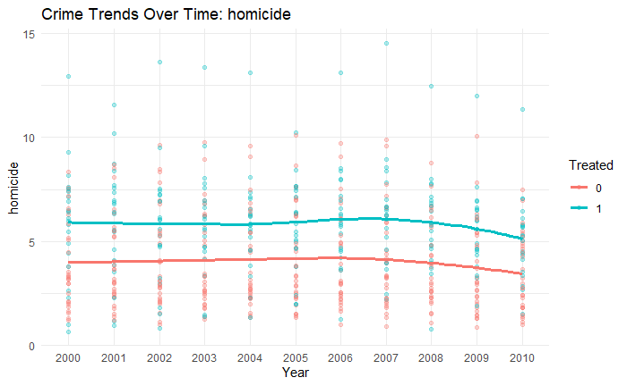

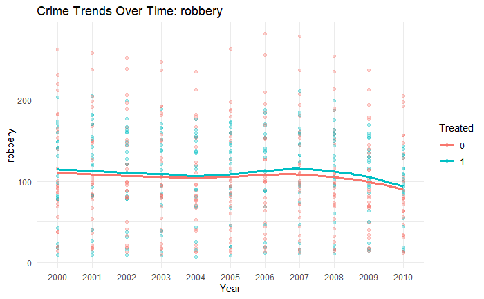

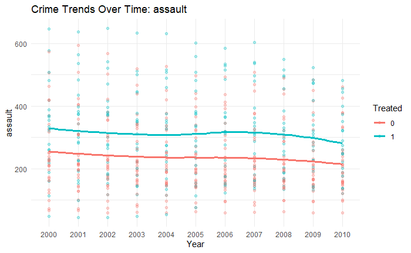

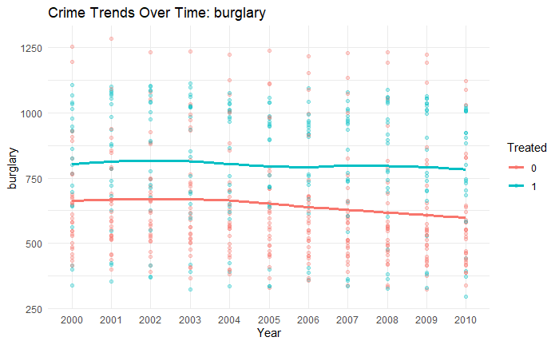

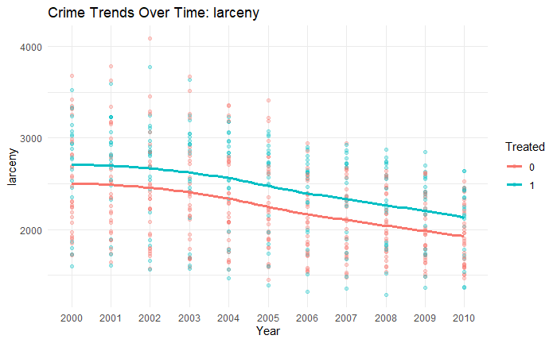

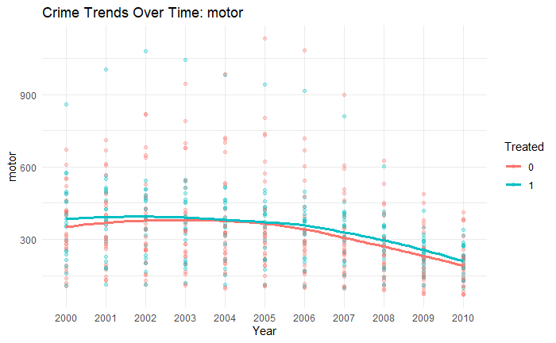

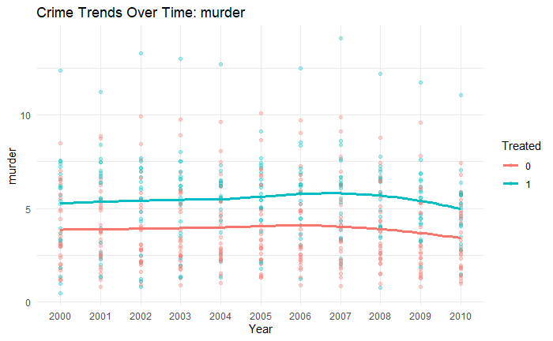

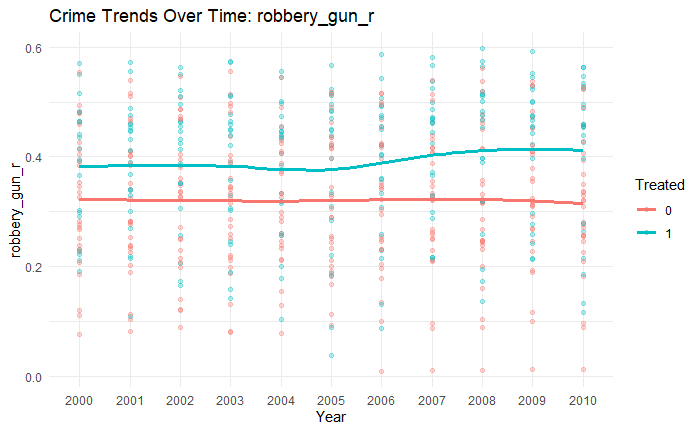

```r
crime_vars <- c("homicide", "robbery", "assault", "burglary", "larceny", "motor", "murder", "robbery_gun_r")

for (var in crime_vars) {
  p1 <- ggplot(data, aes(x = year, y = .data[[var]], group = state, color = as.factor(treated))) +
    geom_point(alpha = 0.3) +
    geom_smooth(aes(group = treated), method = "loess", se = FALSE, size = 1.2) +
   # facet_wrap(~ treated) +
    labs(
      title = paste("Crime Trends Over Time:", var),
      x = "Year",
      y = var,
      color = "Treated"
    ) +
    theme_minimal()

  print(p1)
}
```

### Distributions on covariates

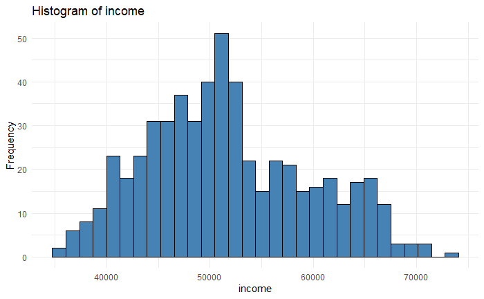

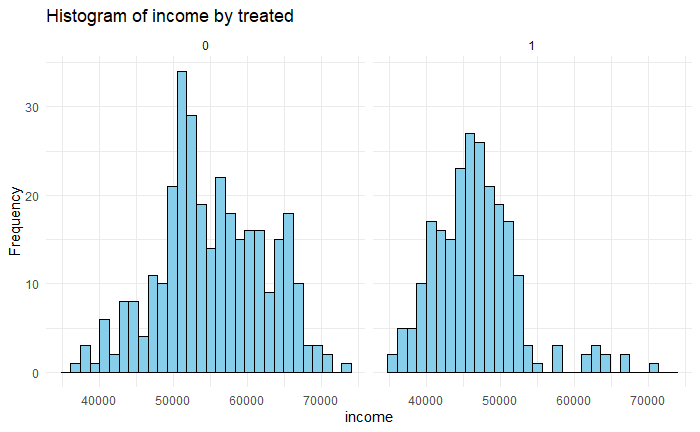

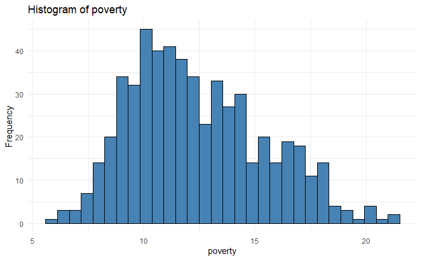

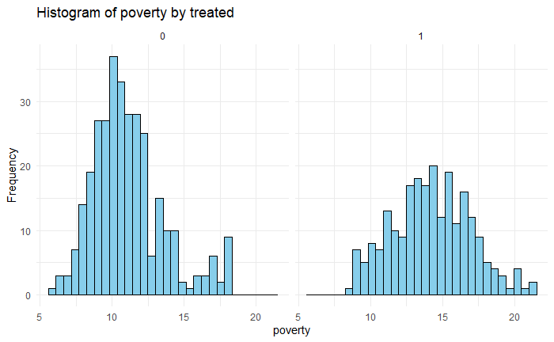

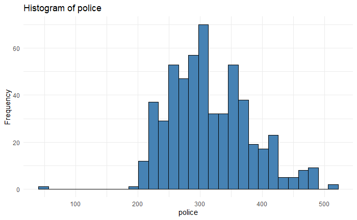

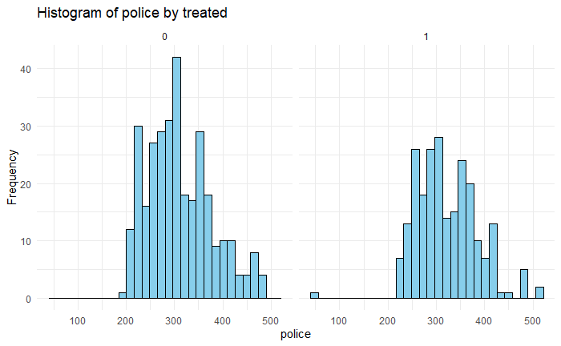

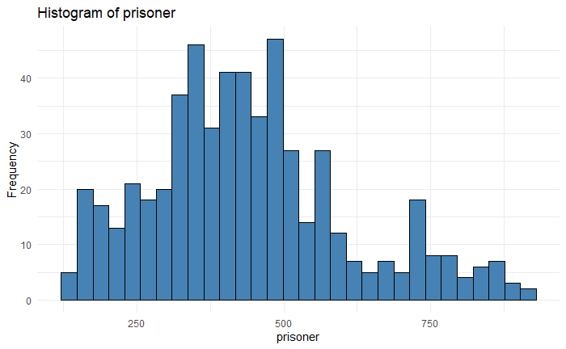

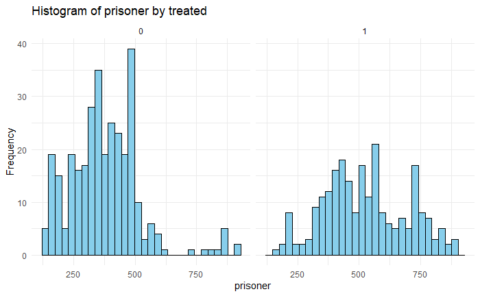

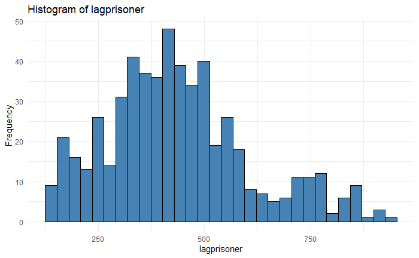

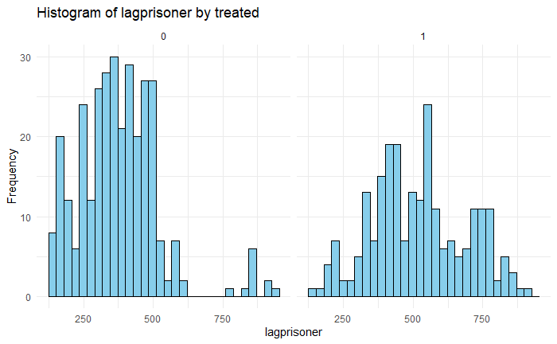

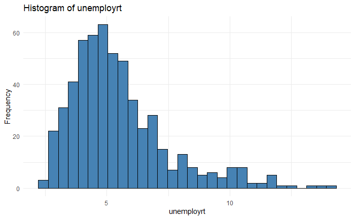

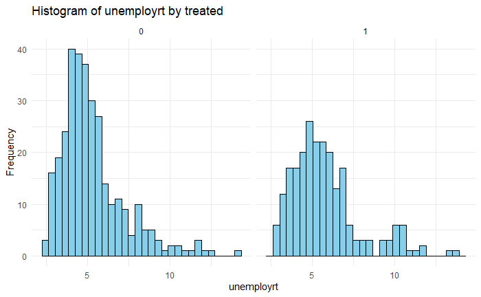

[12 more figures not shown]

```r
socioeconomic_vars <- c("income", "poverty", "police", "prisoner", "lagprisoner", "unemployrt", "exp_subsidy", "exp_pubwelfare")
demographic_vars <- c("blackm_15_24", "whitem_15_24", "blackm_25_44", "whitem_25_44")

for (var in c(socioeconomic_vars, demographic_vars)) {

  p <- ggplot(data, aes_string(x = var)) +
    geom_histogram(bins = 30, fill = "steelblue", color = "black") +
    labs(title = paste("Histogram of", var), x = var, y = "Frequency") +
    theme_minimal()
  print(p)

  q <- ggplot(data, aes_string(x = var)) +
    geom_histogram(bins = 30, fill = "skyblue", color = "black") +
    facet_wrap(~ treated) +
    labs(title = paste("Histogram of", var, "by treated"), x = var, y = "Frequency") +
    theme_minimal()
  print(q)
}
```

For distributions of crime variables, we find that the crime variables generally show fewer extremely large values. Therefore we plan to adopt Log transformation.

For the time trend, we observe a relatively significant change in some of the crime variables around 2005, while the two data sets are largely consistent with the parallel trend hypothesis until about 2005.